# 2 think+type: local scope for variables

```python
import numpy as np
import matplotlib.pyplot as plt
#importing mupy and matplot
```

```python
def fractionofC(v):
    '''

    -----input------

    v: integer or float
    a speed in meters/second

    -----function------

    defines c as 2.998*10^8 m/s
    calulates v/c
    prints("The inputted speed is", v, "the speed of light is, ", c, "v is, " v/c, "muliplied by tehe speed of light")

    ------output-----
    return(v/c)
    this is so if I need to use this function as a quick calculator in the future I can
    '''
    c = 2.998e8 #m/s the speed of light
    # c is a local variable defined only in the function, fractionofC(v)

    #print(f"{c:.3e}")
    #print(f"{v:.3e}")
    print("The inputted speed is, ", f"{v:.3e}", "the speed of light c is, ", f"{c:.3e}", ". ", f"{v:.3e}", " is, ", f"{v/c:.3e}" "muliplied by tehe speed of light")
    #my print statement is printing everything in scientific notation to make it easier to compare the numbers

    #return(v/c) # adding a return statement to allow me to use the function in future calculation if needed
```

```python
fractionofC(234)
```

```
The inputted speed is,  2.340e+02 the speed of light c is,  2.998e+08 .  2.340e+02  is,  7.805e-07muliplied by tehe speed of light
```

```python
fractionofC(3000)
```

```
The inputted speed is,  3.000e+03 the speed of light c is,  2.998e+08 .  3.000e+03  is,  1.001e-05muliplied by tehe speed of light
```

```python
c = "the speed of light so like over 5 meters/second I think"
fractionofC(123456)

print("\n", "outside the function thevalue c is, ", c) #showing that the c inside the function is a local varaible while the c out side the function is a gloabal variable with a different value
```

```
The inputted speed is,  1.235e+05 the speed of light c is,  2.998e+08 .  1.235e+05  is,  4.118e-04muliplied by tehe speed of light

 outside the function thevalue c is,  the speed of light so like over 5 meters/second I think
```

# 3 think+predict+test: local scope for variables

### think+write: local scope

#### my predoction:

y = 2

def add(x, y = 4): return x + y

z = add(2, 3)

in the function add, x is a positional argument and must be inputted

y is a keyword argument that if not entered has a value of 4

z =add(2, 3) assigns z to the value of add(2, 3)

in add(2, 3) 2 is assigned to x and 3 is assigned to y

the function will return x+y which in this case the function will retun 2 + 3 z=add(2,3) will return a value The function will return x+y, which in this case, is the integer 5

```python
#testing my predictions of a return value of 5
y = 2
def add(x, y = 4):
    return x + y
z = add(2, 3)
print(z) #making sure I was correct
```

```
5
```

As predicted, the output of the code in [7] is 5. That means that I probably predicted the code correctly

*There is always the possibility that I completely misunderstood the code and the output just happens to be what I predicted, but I am pretty confident I understand at least the big picture of how the code works and that my prediction was accurate.

# 4 think+debug+write: seeing scopes with debug

```python
#the code im debugging

sigma = 5.67e-8 # W/m**2/K**4
T = 200 # K


def flux(T):
    '''Return the total surface flux for a temperature T,
    from the Stefan-Boltzmann Law.'''
    return sigma*T**4

flux('100')
```

```
---------------------------------------------------------------------------
TypeError                                 Traceback (most recent call last)
Cell In[9], line 12
      8     '''Return the total surface flux for a temperature T,
      9     from the Stefan-Boltzmann Law.'''
     10     return sigma*T**4
---> 12 flux('100')

Cell In[9], line 10, in flux(T)
      7 def flux(T):
      8     '''Return the total surface flux for a temperature T,
      9     from the Stefan-Boltzmann Law.'''
---> 10     return sigma*T**4

TypeError: unsupported operand type(s) for ** or pow(): 'str' and 'int'
```

```python
debug
```

```
> /tmp/ipykernel_3632889/2560422117.py(10)flux()
      8     '''Return the total surface flux for a temperature T,
      9     from the Stefan-Boltzmann Law.'''
---> 10     return sigma*T**4
     11
     12 flux('100')
```

```
'100'
```

```
> /tmp/ipykernel_3632889/2560422117.py(12)<module>()
      8     '''Return the total surface flux for a temperature T,
      9     from the Stefan-Boltzmann Law.'''
     10     return sigma*T**4
     11
---> 12 flux('100')
```

```
200
```

```
<class 'int'>
```

```
> /tmp/ipykernel_3632889/2560422117.py(10)flux()
      8     '''Return the total surface flux for a temperature T,
      9     from the Stefan-Boltzmann Law.'''
---> 10     return sigma*T**4
     11
     12 flux('100')
```

```
<class 'str'>
```

```
5.67e-08
```

```
<class 'float'>
```

### error explanation

The error with the function, flux(T) occurs in the last line of the function.

```python
#testing out my proposed solution from the debug section

sigma = 5.67e-8 # W/m**2/K**4
T = 200 # K


def flux(T):
    '''Return the total surface flux for a temperature T,
    from the Stefan-Boltzmann Law.'''
    T = int(T)
    return sigma*T**4

flux('100')
```

```
5.67
```

The code above seems to have worked, as it returned the correct value for the total surface flux for 100 kelvin using the Stefan-Boltzman Law.

# 5 think+type: keyword arguments

```python
#defining the Gauss function

def gauss(x, A=0.0, B=1.0, mu=0.0, sigma=1.0):
    print(f"Using A={A}, B={B}, mu={mu}, sigma={sigma}\n")
    return A + B * np.exp(-(x - mu)**2 / (2.0 * sigma**2))
```

### ubiquitous Gaussian function

```python
#defining the Gaussian function

def gauss(x, A=0.0, B=1.0, mu=0.0, sigma=1.0):
    print(f"Using x={x}, A={A}, B={B}, mu={mu}, sigma={sigma}\n")
    return A + B * np.exp(-(x - mu)**2 / (2.0 * sigma**2))
```

```python
gauss(1) #testing to make sure I coded it correctly
```

```
Using x=1, A=0.0, B=1.0, mu=0.0, sigma=1.0
```

```
0.6065306597126334
```

```python
gauss(0) #with x = 0, this should return 1.0 if I coded all of the positional and keyword arguments corrcetly
```

```
Using x=0, A=0.0, B=1.0, mu=0.0, sigma=1.0
```

```
1.0
```

# 6 think+pair+code: keyword arguments

### First way of calling Gauss with A of 10.0 and mu of 2.0

just inputting all the values into the function in order, ie: gauss(x, A, B, mu, sigma)

```python
gauss(1, 10.0, 1.0, 2.0, 1.0)
```

```
Using x=1, A=10.0, B=1.0, mu=2.0, sigma=1.0
```

```
10.606530659712634
```

### Second way of calling Gauss with A of 10.0 and mu of 2.0

Naming each variable in the calling of the function ie: gauss(x=1, A=10.0, mu=2)

```python
gauss(x=1, A=10.0, mu=2.0)
```

```
Using x=1, A=10.0, B=1.0, mu=2.0, sigma=1.0
```

```
10.606530659712634
```

# 7 think+write: keyword arguments

## think+write keyword arguments”

def root(a, b=3.0, c=4.0): """ Return the positive root of quadratic equation a * x**2 + b * x + c. """ return (-b + np.sqrt(b**2 - 4 * a * c)) / (2.0 *a) print root(b=4.0)

The goal of this is to compute the positive root of 𝑦 = 𝑥^2 + 4𝑥 + 4

However, this input would return an error. This is because "a" is a positional argument. That means "a" is a required input. If root(4.)) was entered, the function would successfully return a value since b and c are keyword arguments that are not required to be entered. But since root(b=4.0) was entered, it redefines b as 4.0 and leaves the positional argument a blank, so this function would fail and return an error.

# 8 (bonus)+think+type: **kwargs

```python
def test_gauss(**kwargs):
    """This function is useful to make a test plot
    of a Gaussian function. Any keyword arguments
    will be passed through to gauss(). """
    print("The dictionary 'kwargs' contains:")
    print(kwargs)
    x = np.linspace(-10, 10, 100) # creating an array of x values between -10 and 10 with 100 elements
    y = gauss(x, **kwargs) #caling gauus with the array of x values
    plt.scatter(x, y) #creating a scatter plot of the gauss function
```

### using the function test_gauss with no kwargs

[output not shown]

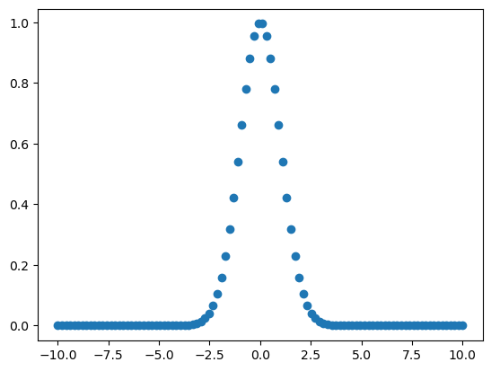

```python
test_gauss() #this should produce a graph using the keyword arguments in the Gauss function along with the arrary of x values as positional arguments generated in the test_gauss function``
```

### using the function test_gauss with kwargs, A=2 and, mu=-7.4

[output not shown]

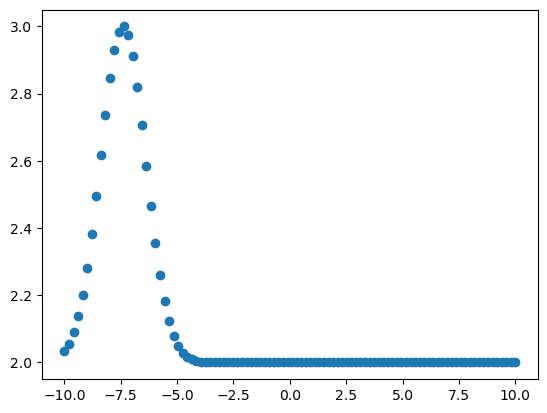

```python
test_gauss(A=2, mu=-7.4)
```

### using the function test_gauss with kwargs, A=-2, sigma=2.0, B=0.3, mu=6.3

[output not shown]

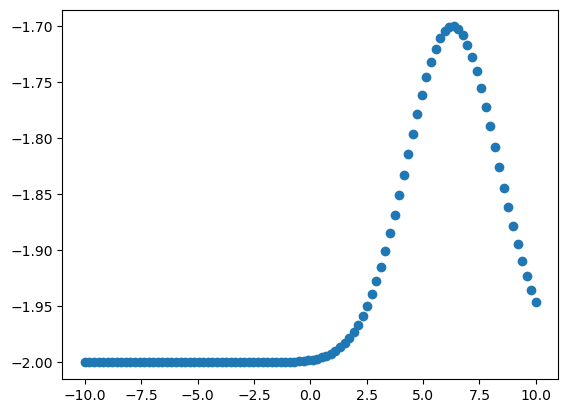

```python
test_gauss(A=-2, sigma=2.0, B=0.3, mu=6.3)
```